# Titanic exercise

## Titanic Exercise from ggplot Tutorial

This is the code that I wrote for the gpplot Tutorial from DataCamp. I used the clean data from the Titanic data wrangling exercies (w/ average ages by class, sex, and survival) so some additional code was needed to produce the graphs from the tutorial.

First, I looked at a bar chart to look at the passengers on board, by class and sex:

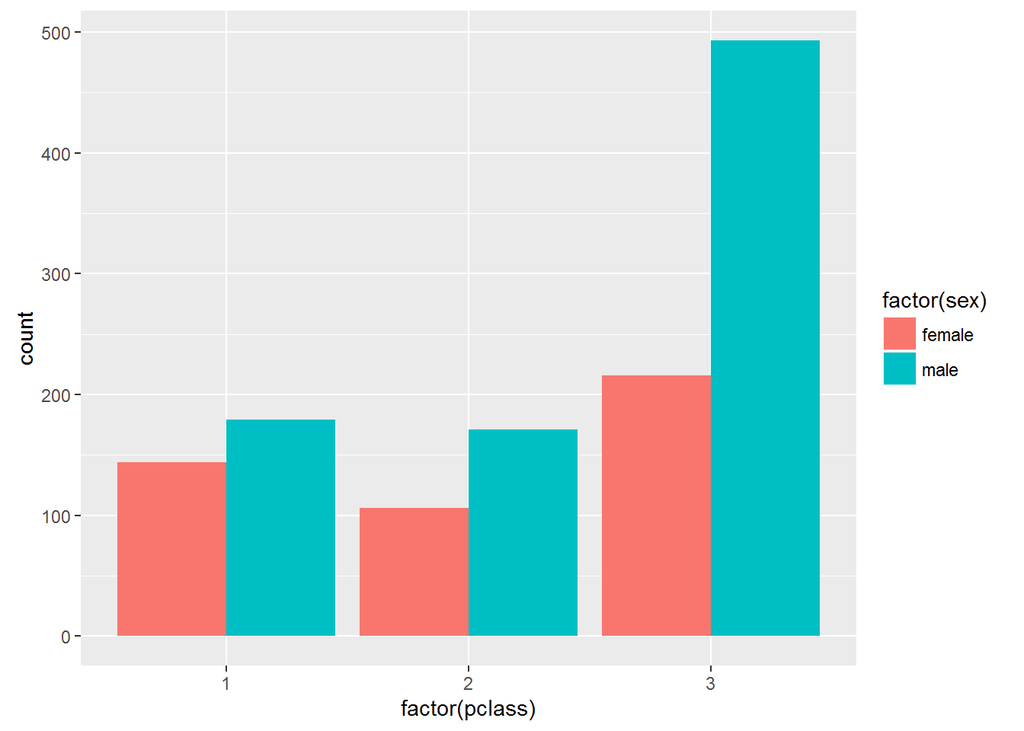

```r
ggplot(na.omit(titanic[ , c('pclass', 'sex', 'survived', 'age')]), aes(x = factor(pclass), fill = factor(sex))) +
  geom_bar(position = 'dodge')
```

### Faceting by Survival

I then looked to see whether there was a difference if the data was faceted by ‘survival’:

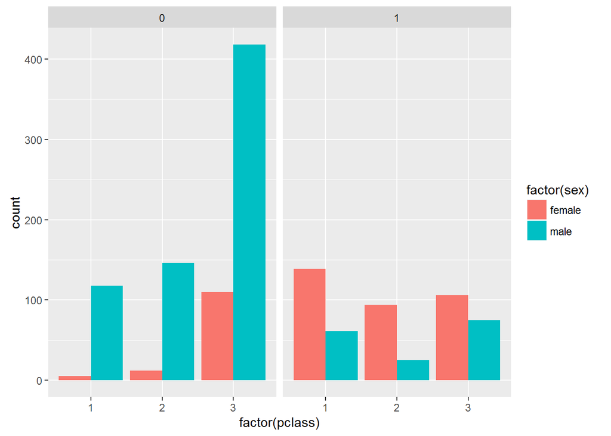

```r
ggplot(na.omit(titanic[ , c('pclass', 'sex', 'survived', 'age')]), aes(x = factor(pclass), fill = factor(sex))) +
  geom_bar(position = 'dodge') +
  facet_grid(. ~ survived)
```

### Adding in Age

It looks like females were more likely to survive, as well as those in 1st class. Does age have any difference?

And finally created a jitter plot with Age as the y axis:

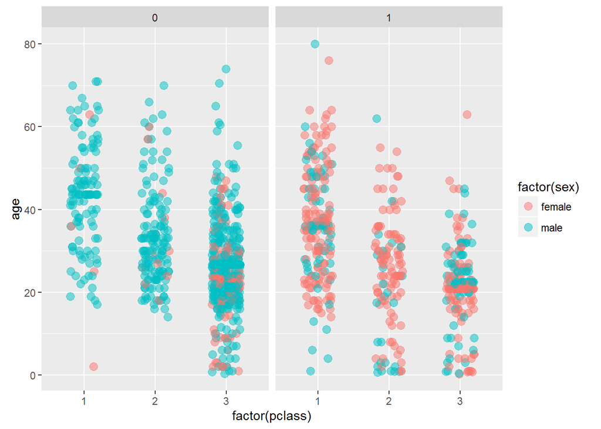

```r
ggplot(na.omit(titanic[ , c('pclass', 'sex', 'survived', 'age')]), aes(x = factor(pclass), y = age, col = factor(sex))) +
  geom_jitter(size = 3, alpha = 0.5, position = posn_j) +
  facet_grid(. ~ survived)
```

## Let’s Dig a little Deeper

### Floating helps

Here we can see that the vast majority of those who got on a boat survived, while very few who couldn’t make it on a boat lived:

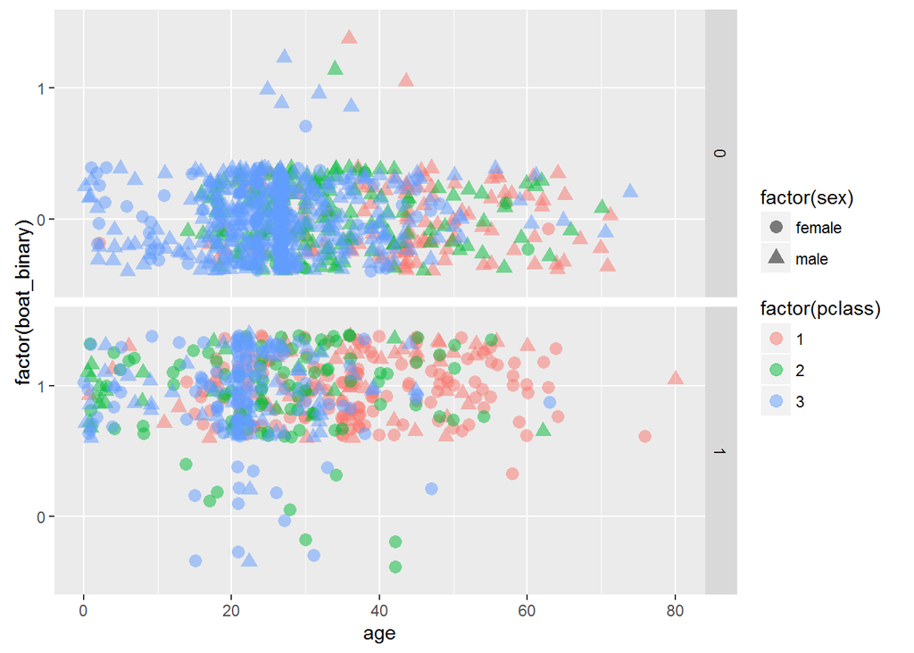

```r
ggplot(na.omit(titanic_2[ , c('pclass', 'sex', 'survived', 'age', 'boat_binary')]),
       aes(x = age, y = factor(boat_binary), col = factor(pclass), shape = factor(sex))) +
  geom_jitter(size = 3, alpha = 0.5, position = posn_j) +
  facet_grid(survived ~ .)
```

### Proportions vs. Raw Counts

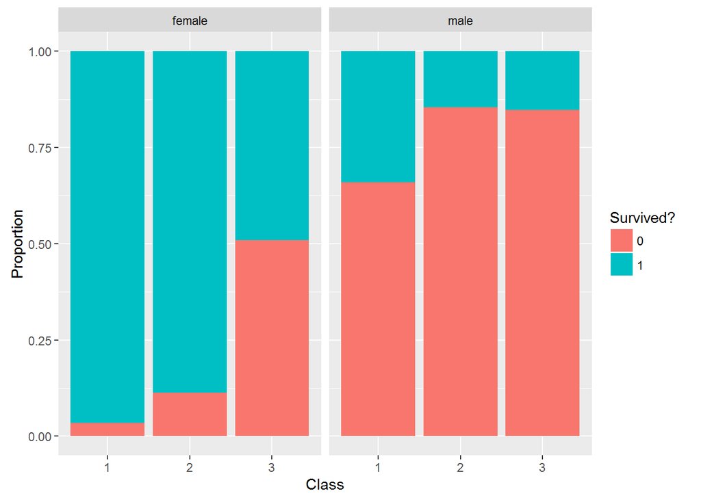

```r
ggplot(na.omit(titanic[ , c('pclass', 'sex', 'survived', 'age')]), aes(x = factor(pclass), fill = factor(survived))) +
  geom_bar(position = 'fill') +
  facet_grid(. ~ sex) +
  labs(x = 'Class', y = 'Proportion', fill = 'Survived?')
```

### Relative Tiers from Exit (by deck)

This is a little research and manual effort on my part, but I wanted to see whether being in a cabin close to a staircase and a deck close to the top was helpful to survival. Using blueprints from [link](https://www.encyclopedia-titanica.org/titanic-deckplans/) I created manual tiers of ‘closeness’ to the top deck. Each deck is a radiates downwards (with A being 1, B being 2… G being 7). All passangers without a cabin listed or with a cabin of T (which I mapped to the Tank deck) was given 8.

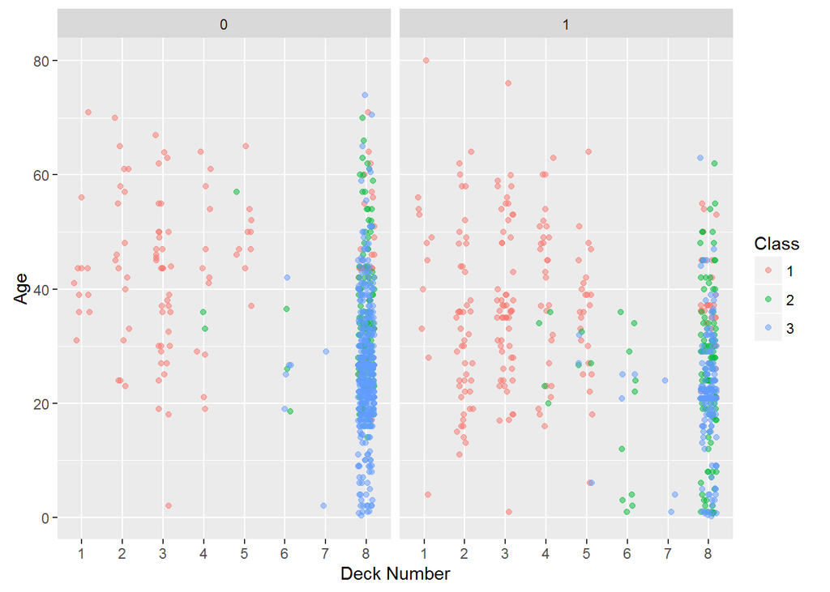

```r
ggplot(na.omit(titanic_2[ , c('pclass', 'sex', 'survived', 'age', 'deck_number')]), aes(x = factor(deck_number), y = age,
                                                                                      col = factor(pclass))) +
  geom_jitter(position = posn_j, alpha = 0.5) +
  facet_grid(. ~ survived) +
  labs(x = 'Deck Number', y = 'Age', col = 'Class')
```

### Survival Rates by Gender, by Class, and by Age Range (in 10 year increments)

```r
titanic_2 %>%
  group_by(sex) %>%
  summarise(mean(survived, na.rm = TRUE))
```

```
## # A tibble: 3 x 2
##      sex mean(survived, na.rm = TRUE)
##    <chr>                        <dbl>
## 1                                 NaN
## 2 female                    0.7274678
## 3   male                    0.1909846
```

```r
titanic_2 %>%
  group_by(pclass) %>%
  summarise(mean(survived, na.rm = TRUE))
```

```
## # A tibble: 4 x 2
##   pclass mean(survived, na.rm = TRUE)
##    <int>                        <dbl>
## 1      1                    0.6191950
## 2      2                    0.4296029
## 3      3                    0.2552891
## 4     NA                          NaN
```

```r
titanic_2 %>%
  group_by(age_range) %>%
  summarise(mean(survived, na.rm = TRUE))
```

```
## # A tibble: 9 x 2
##   age_range mean(survived, na.rm = TRUE)
##      <fctr>                        <dbl>
## 1    (0,10]                    0.5813953
## 2   (10,20]                    0.4024390
## 3   (20,30]                    0.3257443
## 4   (30,40]                    0.4481328
## 5   (40,50]                    0.3421053
## 6   (50,60]                    0.4838710
## 7   (60,70]                    0.2222222
## 8   (70,80]                    0.3333333
## 9        NA                          NaN
```

This high-level data analysis shows at least one thing to be true: the maxim “Women and children first” held true in the case of the Titanic.